# Netflix Titles (2007-2021)

Saksham Tejpal (100874871)

2025-03-24

This project explores the Netflix Titles dataset from Kaggle, which provides a comprehensive view of the movies and TV shows available on Netflix from 2007-2021. This dataset comprise various attributes such as the release year, date added to Netflix, genres, countries of production, and content type. In this assignment, I visualized, investigated and discussed various findings and relations among different attributes. I used dplyr and tidyr for data manipulation and cleaning. A variety of visualizations are then used using ggplot2 and the sf package, including scatterplots, histograms, pie charts, ridgeline plots, stacked bar charts, and choropleth maps.

```r
# Import libraries
library(tidyverse)
library(ggridges)
library(sf)
library(rnaturalearth)
library(rnaturalearthdata)
library(viridis)
library(scales)
library(countrycode)

# Import dataset
netflix <- read_csv("netflix_titles.csv")
```

This analysis begins by converting the “date_added” column into a proper Date format using the mdy() function and extracting the corresponding year of addition. Scatterplot is created to visualize the number of titles added each year. Each point on the plot represents the count of titles that joined Netflix in a specific year, allowing us to observe trends in content acquisition over years. There were minimal amount of shows added from 2008 to 2014, however after 2015 there was exponential growth, with maximum titles added in 2019 at around 2000 titles.

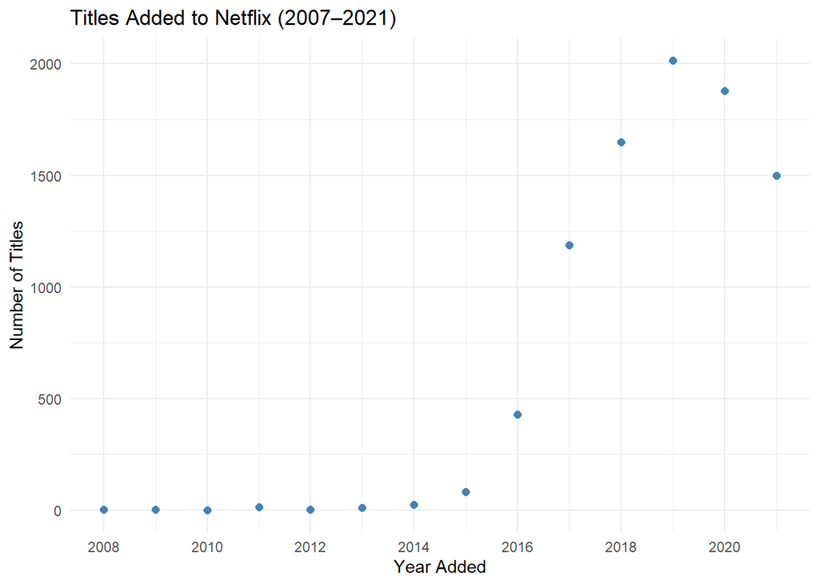

```r
# Format and extract dates
netflix <- netflix |>
  mutate(date_added = mdy(date_added),
         year_added = year(date_added)) |>
  filter(!is.na(year_added))

# ScatterPlot Data
netflix |>
  count(year_added) |>
  ggplot(aes(x = year_added, y = n)) +
  scale_x_continuous(breaks = scales::pretty_breaks(n = 10))+
  geom_point(color = "steelblue", size = 2) +
  labs(x = "Year Added", y = "Number of Titles",
       title = "Titles Added to Netflix (2007–2021)") +
  theme_minimal()
```

Time delay (lag) is calculated next, between when a title is released and when it is added to Netflix. Lag years, are calculated by for all the titles and the average lag across all titles is then computed. Then A histogram is plotted with x-axis constrained to show lag values from 0 to 40 years, as the count of titles added after that were negligible. This helps focus on the most relevant portion of the data while filtering out extreme cases. It was observed that on an average Netflix adds a show after 4.7 years with most shows being added same year. As the lag increases the count of titles decreases.

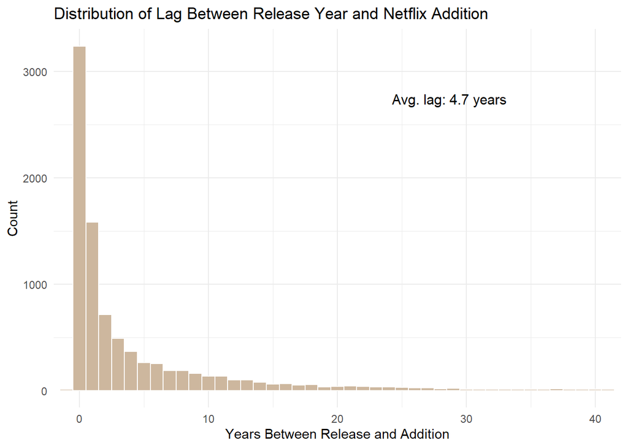

```r
# Compute lag between release year and the year added
netflix <- netflix |>
  mutate(lag_years = year_added - release_year)

# Summarize average lag
avg_lag <- netflix |>
  summarize(avg_lag = mean(lag_years, na.rm = TRUE))

# Histogram of lag years, with 1 to 40 years of lag
netflix |>
  ggplot(aes(x = lag_years)) +
  geom_histogram(binwidth = 1, fill = "bisque3", color = "white") +
  coord_cartesian(xlim = c(0, 40)) +
  labs(x = "Years Between Release and Addition",
       y = "Count",
       title = "Distribution of Lag Between Release Year and Netflix Addition") +
  annotate("text", x = Inf, y = Inf,
           label = paste("Avg. lag:", round(avg_lag, 1), "years"),
           hjust = 2, vjust = 7, size = 4, color = "black") +
  theme_minimal()
```

After that, how the average lag between a title’s release and its addition to Netflix has evolved over time can be examined. The dataset is grouped by the year a title was added, computes the average lag for each year, and then creates a time-series plot. This visualization provides insights into how the delay between release and addition is changing over time.

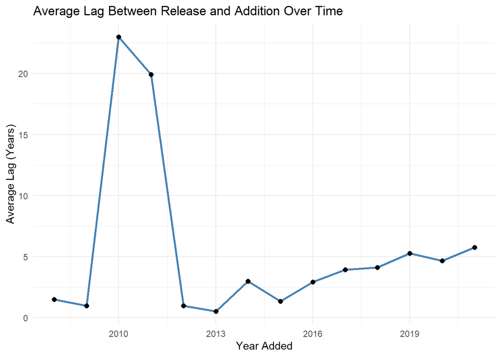

```r
# Compute the average lag per year
avg_lag_year <- netflix |>
  group_by(year_added) |>
  summarize(avg_lag = mean(lag_years, na.rm = TRUE),
            count = n(), .groups = "drop")

# ScatterPlot to Show the change
ggplot(avg_lag_year, aes(x = year_added, y = avg_lag)) +
  geom_line(color = "steelblue", size = 1) +
  geom_point(color = "black", size = 2) +
  labs(x = "Year Added", y = "Average Lag (Years)",
       title = "Average Lag Between Release and Addition Over Time") +
  theme_minimal()
```

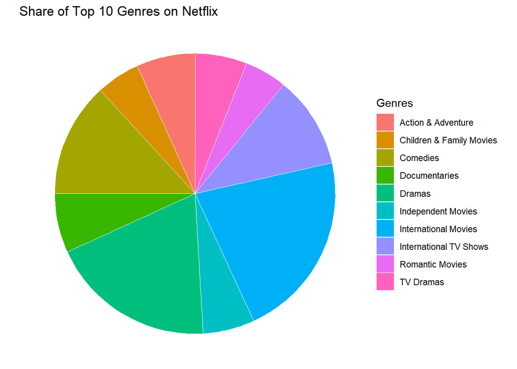

```r
# Separate genres
genres <- netflix |>
  separate_rows(listed_in, sep = ",\\s*")

# Count frequency of each genre
genre_counts <- genres |>
  count(listed_in, sort = TRUE)

# Select the top 10 genres
top10_genres <- genre_counts |>
  slice(1:10)

# Piechart to display split of top 10 genres
ggplot(top10_genres, aes(x = "", y = n, fill = listed_in)) +
  geom_bar(stat = "identity", width = 1, color = "white", size = 0.1) +
  coord_polar(theta = "y") +
  labs(title = "Share of Top 10 Genres on Netflix",
       fill = "Genres") +
  theme_void()
```

Now the addition lag for the top 10 genres, with lag > 1 year is plooted to see the difference of lag as per various genres. After filtering the data, a ridgeline plot is used to display the density distribution of lag times per genre, with genres ordered by their median lag. Action & Adventure had the most median lag, even though most shows added the same year, followed by Romantic and Comedy movies. Documentaries had the least median lag, even with some titles having 60 to 80 years of lag.

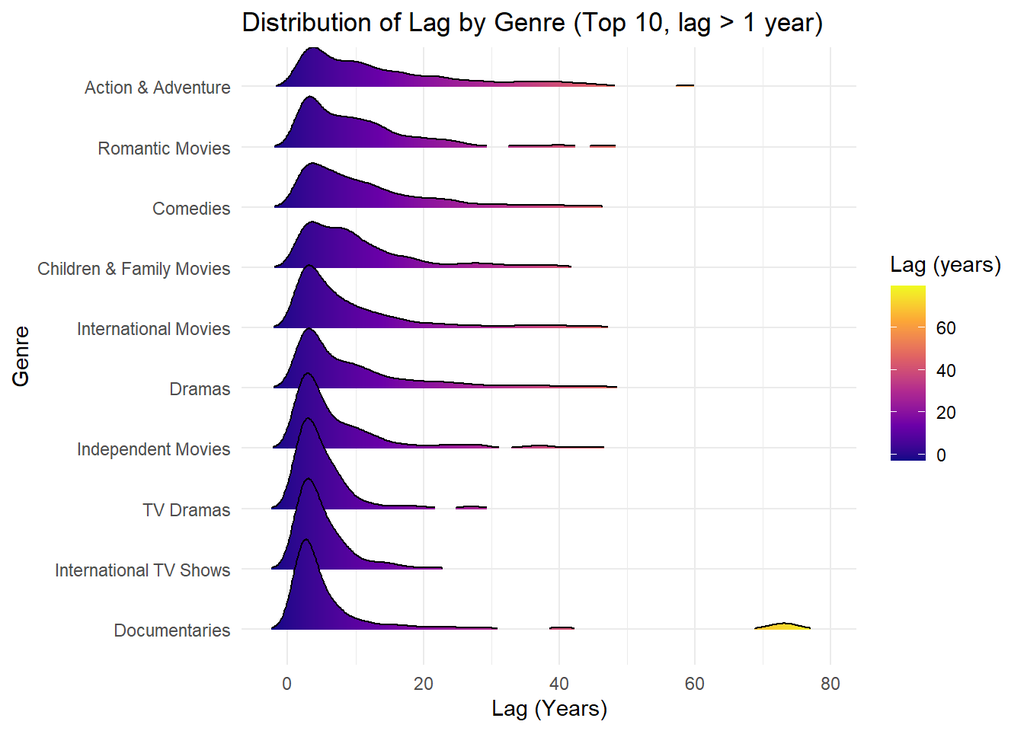

```r
# Filter the top 10 genres and lag_years > 1
top10_genres_1 <- genres |>
  filter(listed_in %in% top10_genres$listed_in, lag_years > 1)

# Ridgeline Plot for Top 10 Genre
ggplot(top10_genres_1, aes(x = lag_years,
             y = fct_reorder(listed_in, lag_years, .fun = median),
             fill = ..x..)) +
  geom_density_ridges_gradient(scale = 1.5, rel_min_height = 0.01) +
  scale_fill_viridis_c(name = "Lag (years)", option = "C") +
  labs(x = "Lag (Years)",
       y = "Genre",
       title = "Distribution of Lag by Genre (Top 10, lag > 1 year)") +
  theme_minimal()
```

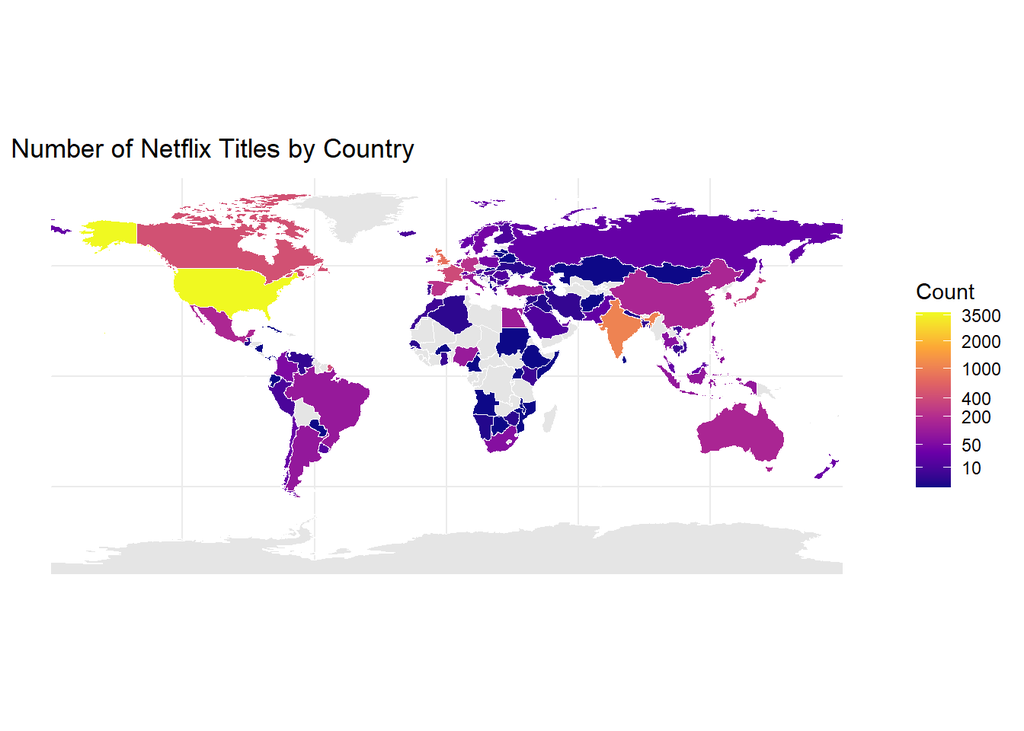

```r
# Separate the country column
countries <- netflix |>
  separate_rows(country, sep = ",\\s*") |>
  filter(!is.na(country) & country != "")

# Adjust country names
countries <- countries |>
  count(country, sort = TRUE) |>
  mutate(country_join = case_when(
    country == "United States" ~ "United States of America",
    country == "UK" ~ "United Kingdom",
    TRUE ~ country
  ))

# World Map Data in sf format
world <- ne_countries(scale = "medium", returnclass = "sf")

# Join the Netflix counts with the world data
world_netflix <- left_join(world, countries, by = c("name" = "country_join"))

# Custom color transformation
power_trans_075 <- trans_new("trans_0.25",
                             transform = function(x) x^0.25,
                             inverse = function(x) x^(1/0.75),
                             format = label_number())

# World Map Plot for Different Countries
ggplot(world_netflix) +
  geom_sf(aes(fill = n), color = "white") +
  scale_fill_viridis_c(
    option = "plasma",
    trans = power_trans_075,
    na.value = "grey90",
    breaks = c(10, 50, 200, 400, 1000, 2000, 3500),
    labels = c("10", "50", "200", "400", "1000", "2000", "3500")
  ) +
  labs(title = "Number of Netflix Titles by Country",
       fill = "Count") +
  theme_minimal()
```

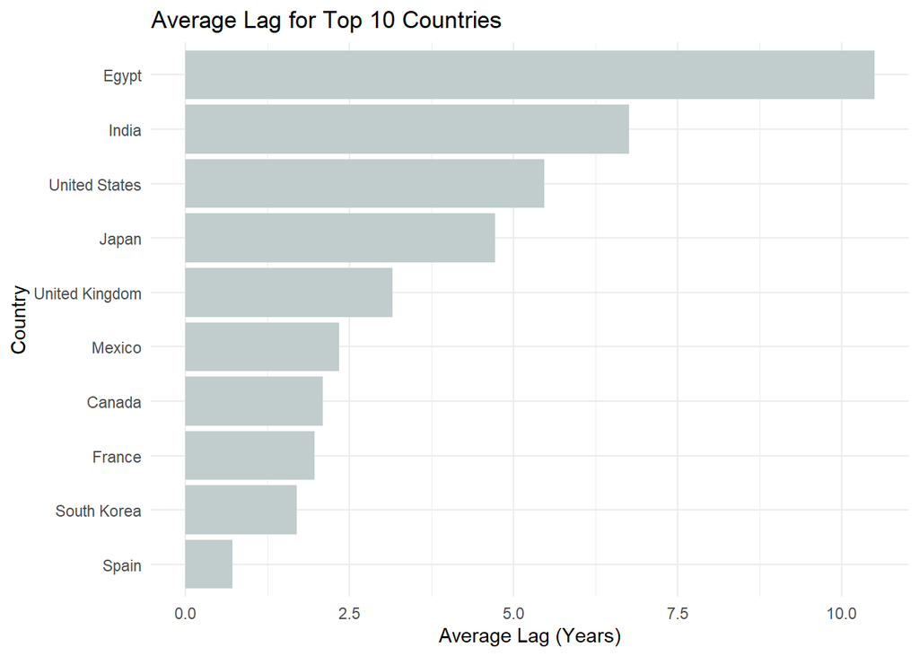

```r
# Summarize average lag per country
avg_lag_country <- netflix |>
  filter(!is.na(country) & country != "") |>
  group_by(country) |>
  summarize(avg_lag = mean(lag_years, na.rm = TRUE),
            count = n(), .groups = "drop")

# Top 10 Countries
top10_countries <- avg_lag_country |>
  slice_max(count, n = 10)

# Plot average lag for the top 10 countries by count
ggplot(top10_countries, aes(x = fct_reorder(country, avg_lag), y = avg_lag)) +
  geom_col(fill = "azure3") +
  coord_flip() +
  labs(x = "Country", y = "Average Lag (Years)",
       title = "Average Lag for Top 10 Countries") +
  theme_minimal()
```

Now, the genre composition of Netflix titles across the top 10 countries is explored. The data is first prepared by splitting both the “country” and “listed_in” columns into individual rows and filtering out missing values. Then, the top 5 genres are selected, and the dataset is filtered to include only these genres in the top 10 countries. A stacked bar chart is created, where each bar represents a country and the segments within the bar show the count of titles in each of the top 5 genres. Visualization shows, how the difference between USA and India is reduced, where India was producing a lot of international movies, while USA producing more dramas for the top 5 genres.

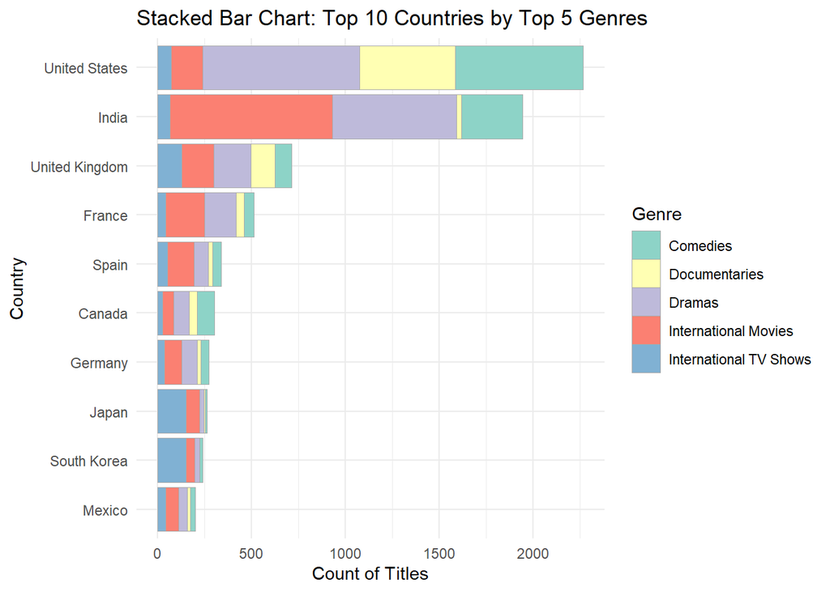

```r
# Separate the country column
netflix_country_genre <- netflix |>
  separate_rows(country, sep = ",\\s*") |>
  separate_rows(listed_in, sep = ",\\s*") |>
  filter(!is.na(country) & country != "",
         !is.na(listed_in) & listed_in != "")

# Select the top 5 genres
top5_genres <- genre_counts |>
  slice(1:5) |>
  pull(listed_in)

# Select the top 10 Countries
top10_countries <- netflix_country_genre %>%
  count(country, sort = TRUE) %>%
  slice_max(n, n = 10) %>%
  pull(country)

# Filter dataset for top countries and genres
stack_data <- netflix_country_genre |>
  filter(country %in% top10_countries,
         listed_in %in% top5_genres) |>
  count(country, listed_in)

# Stacked bar chart
ggplot(stack_data, aes(x = fct_reorder(country, n, sum), y = n, fill = listed_in)) +
  geom_bar(stat = "identity",color = "darkgrey", size = 0.01) +
  coord_flip() +
  scale_y_continuous(breaks = scales::pretty_breaks(n = 5))+
  scale_fill_brewer(palette = "Set3") +
  labs(x = "Country", y = "Count of Titles",
       title = "Stacked Bar Chart: Top 10 Countries by Top 5 Genres",
       fill = "Genre") +
  theme_minimal()
```

Finally, the delay between a title’s release and its addition to Netflix (lag) varies across different genres and countries is explored. First, the top 10 genres are identified from the separated genre data. Then, the dataset is filtered to include only the top 10 countries and these top 10 genres, and the average lag along with title counts is computed for each country–genre combination. To streamline the map, country names are converted to their ISO2 codes using the countrycode package.A heatmap is produced where the x-axis displays the countries (ordered by overall title count), the y-axis shows the genres, and the fill color indicates the average lag. Numerical labels on each tile further clarify the average delay.

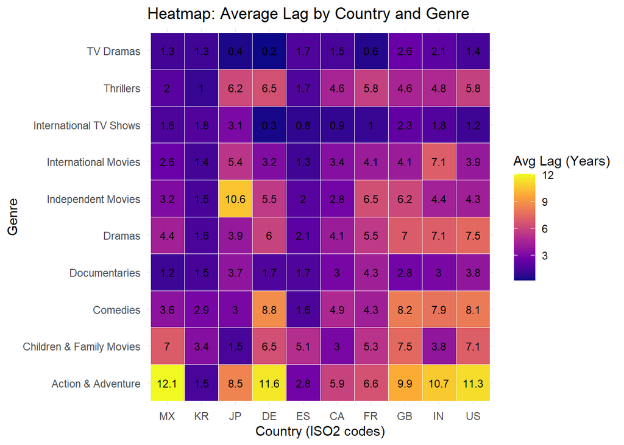

```r
# Compute top 10 genres from the same dataset
top10_genres <- netflix_country_genre |>
  count(listed_in, sort = TRUE) |>
  slice_max(n, n = 10) |>
  pull(listed_in)

# Aggregate average lag and count for each country and genre
lag_country_genre <- netflix_country_genre |>
  filter(country %in% top10_countries,
         listed_in %in% top10_genres) |>
  group_by(country, listed_in) |>
  summarize(avg_lag = mean(lag_years, na.rm = TRUE),
            count = n(), .groups = "drop") |>
  # Convert country names to ISO2 codes
  mutate(country_abbr = countrycode(country, origin = "country.name", destination = "iso2c"))

# Create a heatmap using the aggregated data
ggplot(lag_country_genre, aes(x = fct_reorder(country_abbr, count, sum), y = listed_in, fill = avg_lag)) +
  geom_tile(color = "white") +
  geom_text(aes(label = round(avg_lag, 1)), size = 3, color = "black") +
  scale_fill_viridis_c(option = "plasma") +
  labs(x = "Country (ISO2 codes)", y = "Genre",
       title = "Heatmap: Average Lag by Country and Genre",
       fill = "Avg Lag (Years)") +
  theme_minimal()
```